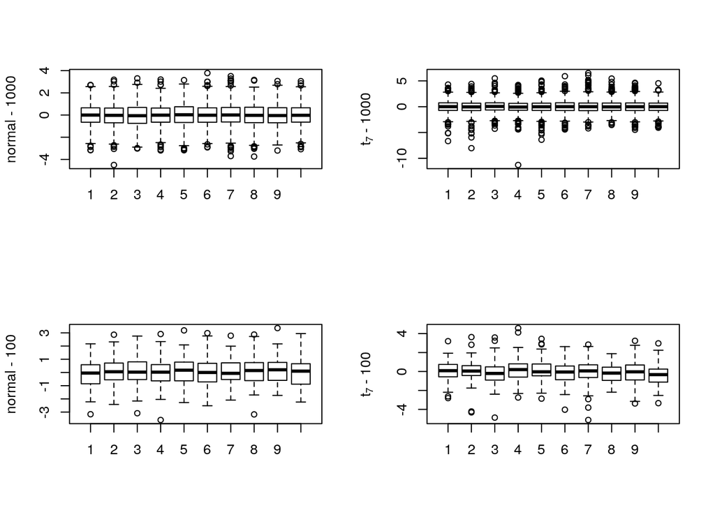

```r
set.seed(151)
oldpar <- par(mfrow=c(2,2))

tenfold1000 <- rep(1:10, rep(1000,10))

boxplot(split(rnorm(1000*10), tenfold1000), ylab="normal - 1000")
boxplot(split(rt(1000*10, 7), tenfold1000),
        ylab=expression(t[7]*" - 1000"))

tenfold100 <- rep(1:10, rep(100, 10))

boxplot(split(rnorm(100*10), tenfold100), ylab="normal - 100")
boxplot(split(rt(100*10, 7), tenfold100),
        ylab=expression(t[7]*" - 100"))
```

```r
par(oldpar)
```

The analisys over these boxplots follows a top-down structure. So, the first things that we may say are related with the mean. In fact each set of $10$ boxplots have, more or less, the same mean value, i.e. around $0$, but with a very small fluctuation in the $100$ samples cases. The same happens on the maximum and minimum values but with different values in case the samples come from a normal distribution or $t$ distribution, but in this case we have to look according to which distribution the samples belong to (more details will be given later). Last comment on the overall boxplots is about the box-size defined by the quantiles: as we can see the box-size for the normal distributions is larger than the box-size for the $t$ distribution, also if we consider the set of boxplots with less samples.

The boxplot might detect some points like a possible outliers, and this is shown by the set of points outside the “whiskers”; in particular, more far from the first and third quantiles they are and more suitable they are to be outliers. Moreover, from the heavy-tailed definition we know that a general distribution is classified as an heavy-tailed if its boxplot shows some candidate outliers in both sides of the “whiskers”, otherwise it is classfied as a skewed distribution (i.e. we detect some outliers in just one of the two sides).

So, in this case we may suspect to deal with a heavy-tailed distribution, and more than half boxes have some plausibles outliers (i.e. they are far enough from the “whiskers”).

In the top-right quarter we have a $t$ distribution and this case is very similar to the first one, but having different values for min, max and quantiles. Moreover, these parameters remain fixed and the “whiskers” have the same length, so the symmetry is respected. In the end, for what concerns possible outliers and heavy-tailed configuration we have to be careful, because most of the outside points are very close to each other and very close to the “whiskers” borders, so it is not so immediate to say something; a more deep analysis is suggested in this case.